# Final Project

Jiawei Li

2017/12/18

# Text analysis

Topic #Rihanna

Topic #Taylor Swift

## Search Topic

First search 5000 results of the topic #Rihanna from Twitter.

It looks like most of the data points I collected are in the area of Europe and United States.

```
## [1] 85
```

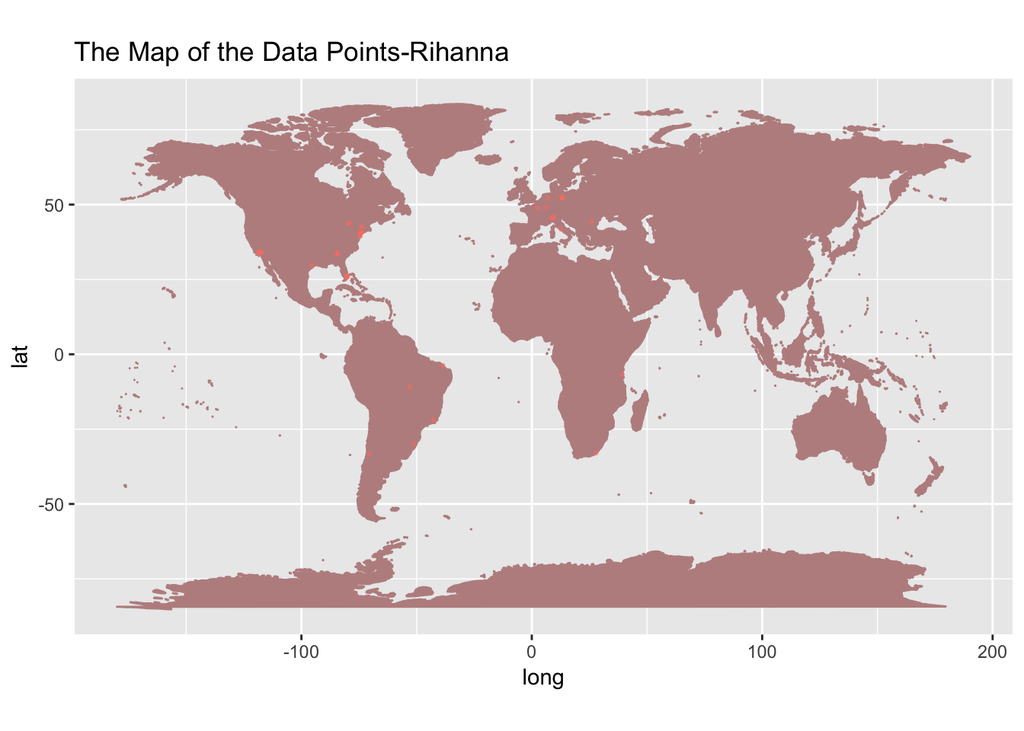

## Calculate the count of tweets by platform.

Here is the barplot of the count of the source Most of the tweets are from Android, and then is Iphone.

| statusSource | n | percent_of_tweets |
| --- | --- | --- |
| Twitter for Android | 1151 | 0.230 |
| Twitter for iPhone | 948 | 0.190 |
| Twitter Web Client | 773 | 0.155 |
| twittbot.net | 430 | 0.086 |
| Instagram | 375 | 0.075 |

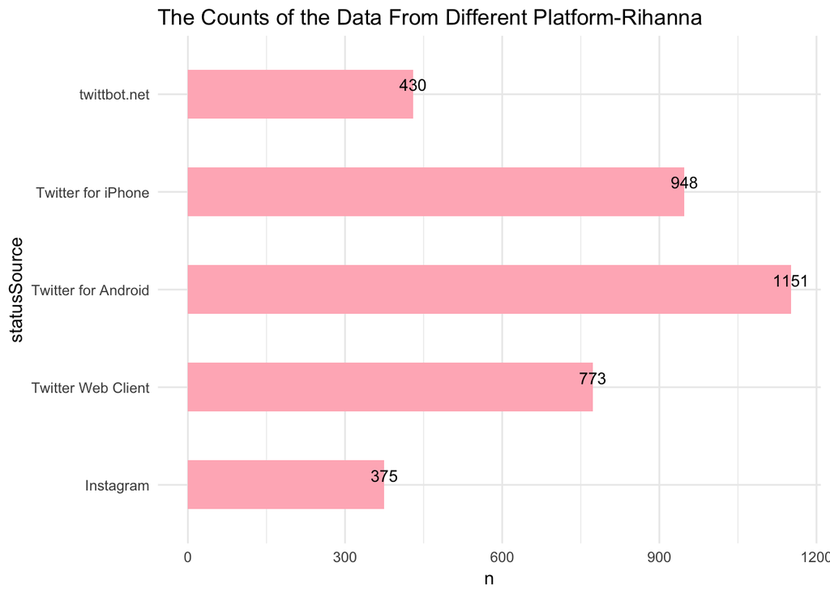

## Sentiment of total data

After clean the data, plot the Sentiment of Topic #Rihanna in total. We can see that most of the words are positive in the topic of #Rihanna. The least is disgust.

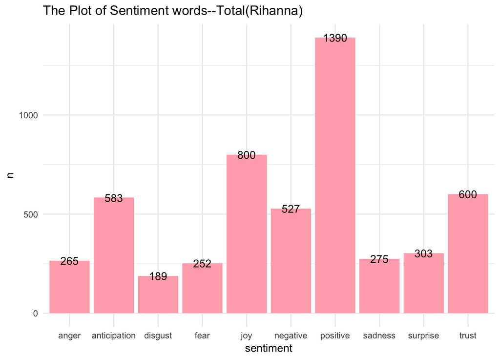

Calculate and plot the Sentiment of Topic #Rihanna from different data source platform. By comparing the sentiment from different data platforms, we can see that positive and joy words have biggest part in the bar.

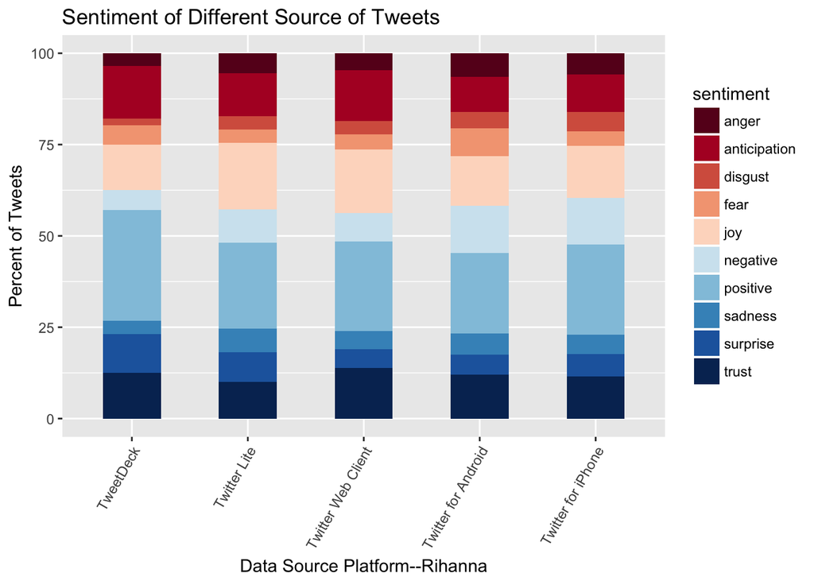

## Wordclouds Analysis–Top 10 words in the Topic(#Rihanna)

Plot the word coulds of #Rihanna. Top 1 word is rihanna, which is obviously. But it is suprise that the secon word is bieber. We can also see that fentybeauty—the cosmetics brand establised by Rihanna herself is also in top 10.

```
##  chr [1:39621] "videos" "100m" "views" "#rihanna" "#taylorswift" ...
```

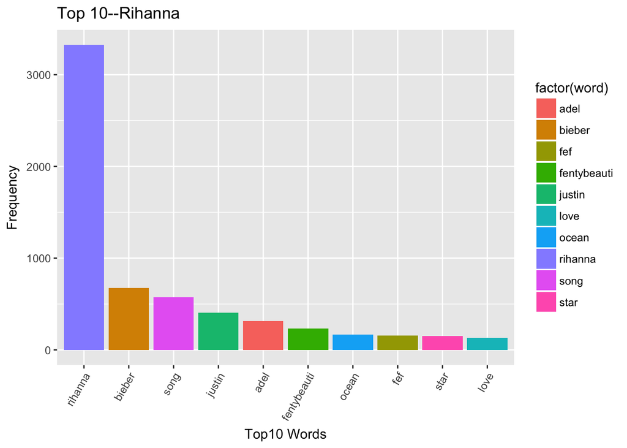

## The Word clouds

Here is the word clouds of the topic #Rihanna.

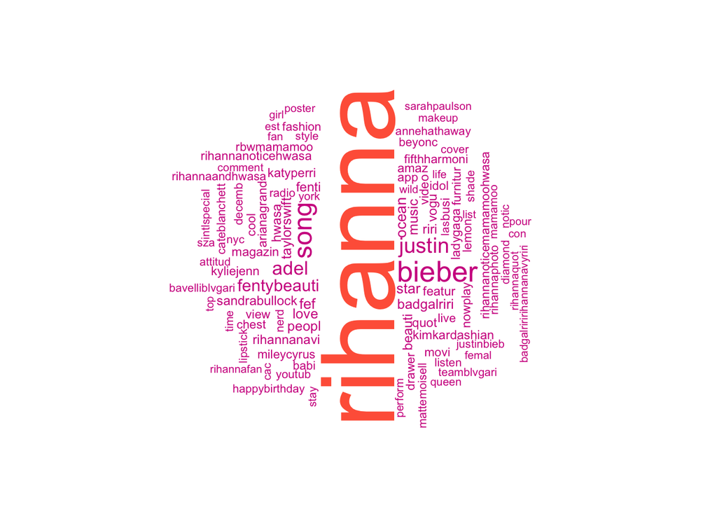

# Analysis of Taylor Swift

## Search Topic

First search 5000 results of the topic #Taylor Swift from Twitter. It looks like most of the majority part of points I collected are in the United States. There is no points in the Africa.

```
## [1] 32
```

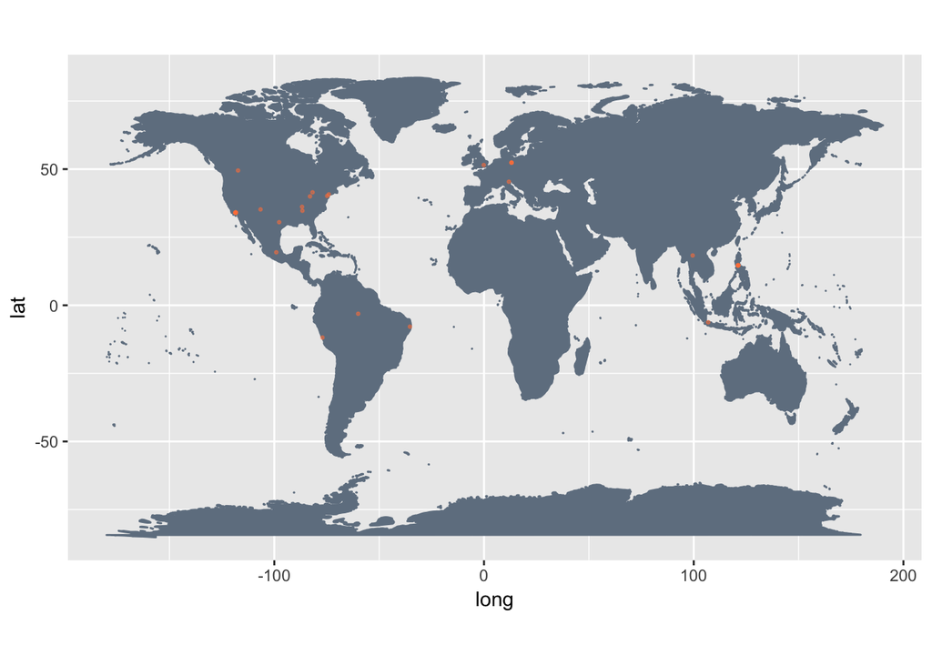

## Calculate the count of tweets by platform.

Here is the table of the count of the source. Different from #Rihanna, most of the tweets contain topic #Taylor Swift are sent from IPhone.

| statusSource | n | percent_of_tweets |
| --- | --- | --- |
| Twitter for iPhone | 1670 | 0.334 |
| Twitter for Android | 1616 | 0.323 |
| Twitter Web Client | 501 | 0.100 |
| xvlog application | 238 | 0.048 |
| Twitter Lite | 157 | 0.031 |

## Barplot of the count of the source

Here is the barplot of the count of the source.

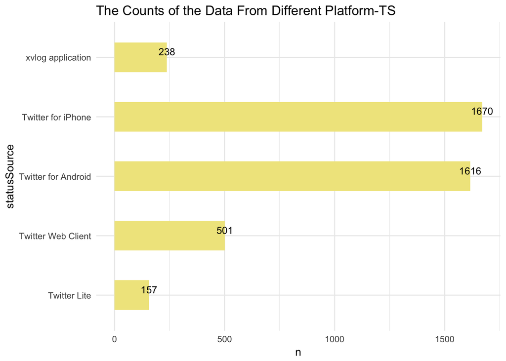

## Sentiment of total

After clean the data, plot the Sentiment of Topic #Taylor Swift in total. The result below shows that positive words appear frequently in the topic of Taylor Swift.

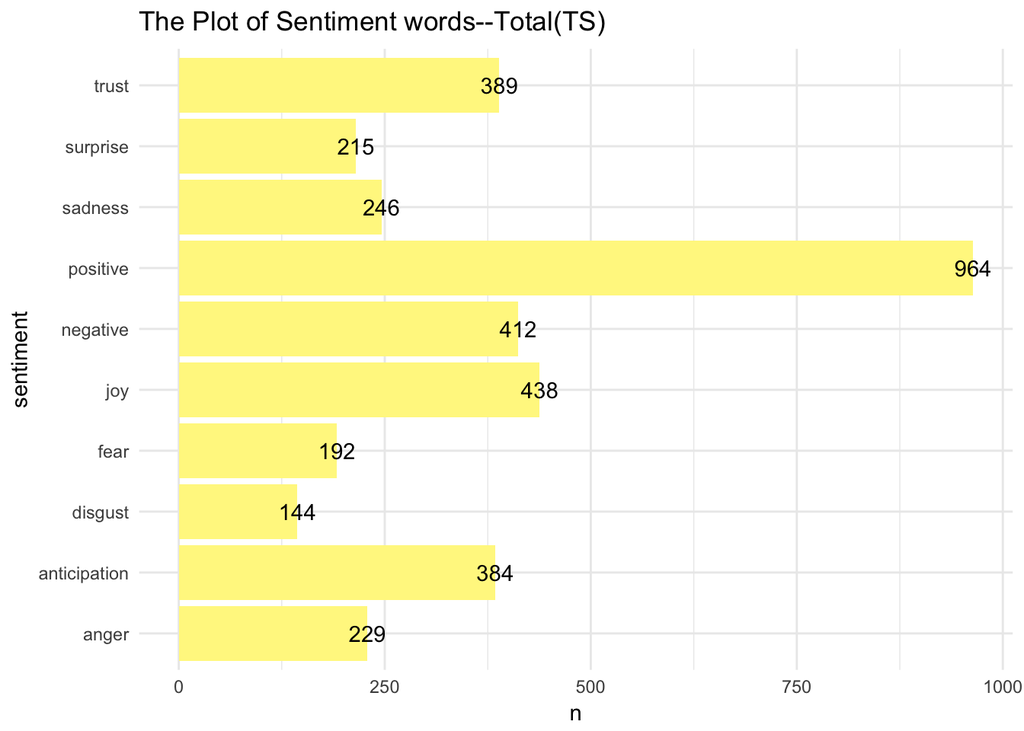

Calculate and plot the Sentiment of Topic #Taylor Swift from different data source platform. The results is similar to the topic of #Rihanna.

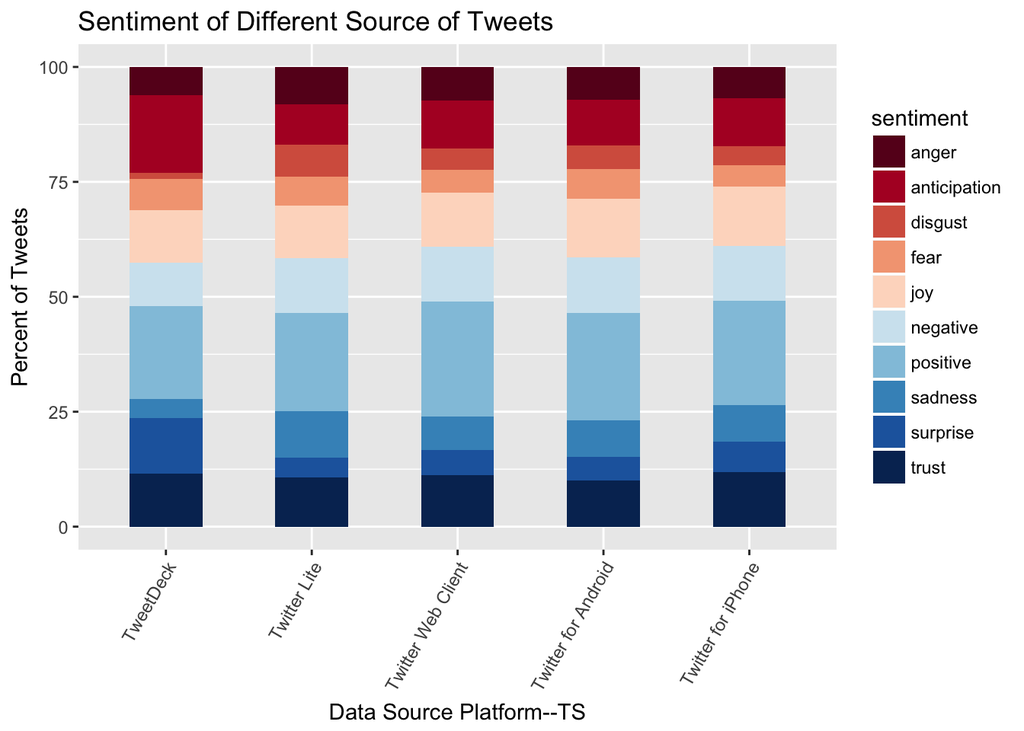

## Wordclouds Analysis–Top 10 words in the Topic(#Taylor Swift)

The character of “Taylor Swift” appears a lot in the top 10 words.

```
##  chr [1:24497] "#demilovato" "#taylorswift" "#beyonc" "00e9" ...
```

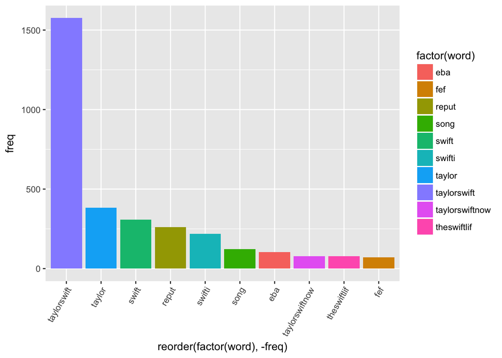

## The Word Clouds

Here is the word clouds of topic #Taylor Swift.

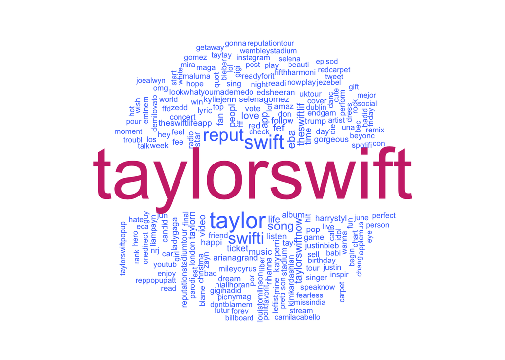